# R Project: Community Garden Crop Yield Optimization via Linear Programming

Amran Haji Omar

2026-03-28

### Problem Formulation

The objective of the project was to determine the optimal area allocation for three crops to maximize total nutritional yield (kilocalories) within strict resource constraints, while meeting a baseline protein requirement for the community.

Let the decision variables represent the area allocated to each crop in square feet:

- $x_1$: Tomatoes
- $x_2$: Carrots
- $x_3$: Beans

### Resource Constraints

- Physical area: $\le 1000$ sq ft
- Water allocation: $\le 800$ gallons/week
- Labor capacity: $\le 80$ hours/week

### Proportional Diversity Constraints

To ensure a diverse yield, no single crop may exceed 40% of the total allocated area:

- **Tomatoes ($x_1$):** $0.6x_1 - 0.4x_2 - 0.4x_3 \le 0$
- **Carrots ($x_2$):** $-0.4x_1 + 0.6x_2 - 0.4x_3 \le 0$
- **Beans ($x_3$):** $-0.4x_1 - 0.4x_2 + 0.6x_3 \le 0$

### Nutritional Demand Constraints (Protein)

The garden was modeled to provide a supplemental food source (20% of total dietary requirements) for 10 adults.

- Average adult requirement: 50g per day (350g per week).
- Total community demand (10 adults): 3,500g per week.
- Supplemental target (20%): 700g per week.

Protein yield per square foot is calculated as: * **Tomatoes ($x_1$):** 2 lbs/sq ft $\times$ 4g/lb = 8g/sq ft * **Carrots ($x_2$):** 1 lb/sq ft $\times$ 4g/lb = 4g/sq ft * **Beans ($x_3$):** 0.5 lbs/sq ft $\times$ 90g/lb = 45g/sq ft

The minimum protein constraint is formulated as:
$$8x_1 + 4x_2 + 45x_3 \ge 700$$

### Objective Function Normalization (Kilocalories)

Applying standard caloric densities to the physical yield rates normalizes the objective function to maximize total kilocalories ($Z$):

- **Tomatoes ($x_1$):** $2 \text{ lbs/sq ft} \times 80 \text{ kcal/lb} = 160 \text{ kcal/sq ft}$
- **Carrots ($x_2$):** $1 \text{ lbs/sq ft} \times 185 \text{ kcal/lb} = 185 \text{ kcal/sq ft}$
- **Beans ($x_3$):** $0.5 \text{ lbs/sq ft} \times 140 \text{ kcal/lb} = 70 \text{ kcal/sq ft}$

$$\max Z = 160x_1 + 185x_2 +
70x_3$$

### Optimization Model

The optimal crop allocation was computed using the simplex algorithm via the `lpSolve` package in R.

```r
# Load lpSolve
library(lpSolve)

# Objective function coefficients (kcal/sq ft)
obj <- c(160, 185, 70)

# Constraint matrix (Area, Water, Labor, Max T, Max C, Max B, Min Protein)
con <- matrix(c(
  1, 1, 1,
  1, 0.5, 0.5,
  0.1, 0.05, 0.05,
  0.6, -0.4, -0.4,
  -0.4, 0.6, -0.4,
  -0.4, -0.4, 0.6,
  8, 4, 45
), nrow = 7, byrow = TRUE)

# Constraint directions
dir <- c("<=", "<=", "<=", "<=", "<=", "<=", ">=")

# Constraint bounds
rhs <- c(1000, 800, 80, 0, 0, 0, 700)

# Execute optimization
sol <- lp("max", obj, con, dir, rhs)

# Output results
cat("Maximized Nutritional Yield (kcal):", sol$objval, "\n\n")
```

```
## Maximized Nutritional Yield (kcal): 152000
```

```r
cat("Optimal Area Allocation (sq ft):\n")
```

```
## Optimal Area Allocation (sq ft):
```

```r
cat("Tomatoes:", sol$solution[1], "\n")
```

```
## Tomatoes: 400
```

```r
cat("Carrots: ", sol$solution[2], "\n")
```

```
## Carrots:  400
```

```r
cat("Beans:   ", sol$solution[3], "\n")
```

```
## Beans:    200
```

```r
# Calculate resulting protein
total_protein <- (8 * sol$solution[1]) + (4 * sol$solution[2]) + (45 * sol$solution[3])
cat("\nTotal Protein Yield (g):", total_protein, "\n")
```

```
##
## Total Protein Yield (g): 13800
```

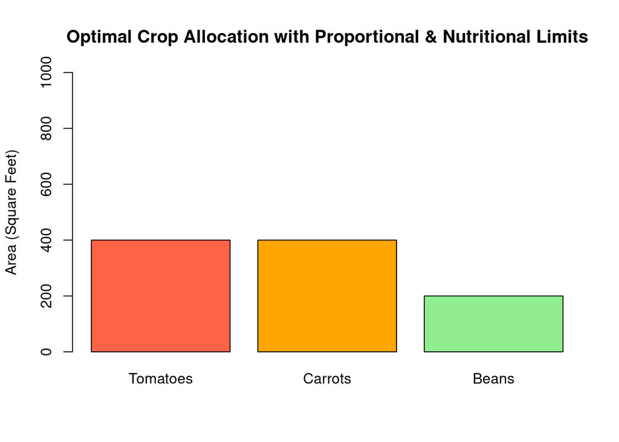

```r
# Visualize optimal allocation
crops <- c("Tomatoes", "Carrots", "Beans")

barplot(
  sol$solution,
  names.arg = crops,
  col = c("#ff6347", "#ffa500", "#90ee90"),
  main = "Optimal Crop Allocation with Proportional & Nutritional Limits",
  ylab = "Area (Square Feet)",
  ylim = c(0, 1000)
)
```

### Results Interpretation

The solver determined the optimal crop distribution to be $x_1 = 400$ sq ft (Tomatoes), $x_2 = 400$ sq ft (Carrots), and $x_3 = 200$ sq ft (Beans).

The $700$g minimum protein constraint is “non-binding” because the optimal solution natively exceeds it.

- **Forced Allocation:** The $40\%$ maximum area rule restricts primary crops, forcing a $200$ sq ft allocation to beans.
- **Protein Surplus:** At $45$g per sq ft, beans alone generate $9,000$g of protein.
- **Total Yield:** Combined with tomatoes ($3,200$g) and carrots ($1,600$g), the weekly output reaches $13,800$g, far exceeding the $700$g requirement.

### References

Cornell University Cooperative Extension. (n.d.). *Recommended spacing and expected yield for garden vegetables in New York*. https://gardening.cals.cornell.edu/files/Recommended-spacing-and-expected-yield-for-garden-vegetables-in-New-York-1iozy2c.pdf

Kansas State University Agricultural Experiment Station and Cooperative Extension Service. (n.d.). *Vegetable garden planting guide*. https://bookstore.ksre.ksu.edu/pubs/vegetable-garden-planting-guide-revised_MF315.pdf

Penn State Extension. (n.d.). *Vegetable seed planting guide*. Pennsylvania State University. https://extension.psu.edu/programs/master-gardener/counties/york/vegetable-guides/vegetable-seed-planting-guide/@@download/file/Vegetable-Seed-Planting-Guide.pdf